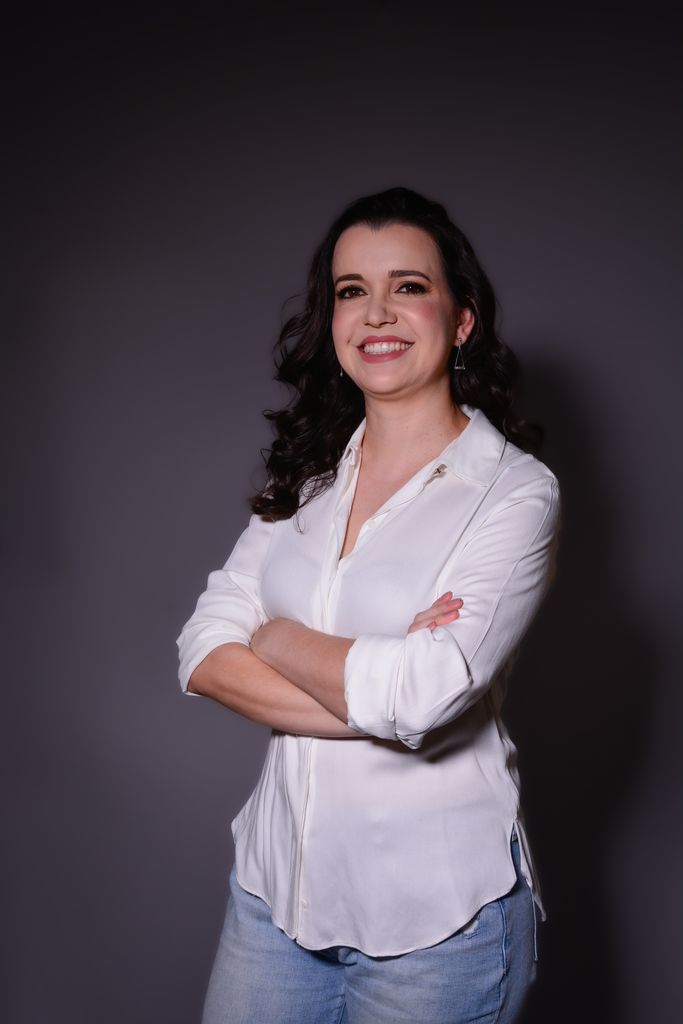

# Katia Lopes, PhD

## Bio

Computational scientist with experience in genetics and multi-modal data analysis, interested in understanding how things work at the molecular level. Expertise in systems biology and multi-omics integration approaches for data-driven insights and biomarker discovery.

## Education

**Federal University of Minas Gerais (UFMG)** | Belo Horizonte, Brazil

- PhD in Bioinformatics | 2013 - 2017

**Federal University of Paraná (UFPR)** | Curitiba, Brazil

- MSc in Bioinformatics | 2011 - 2012

**Anhanguera University** | Belo Horizonte, Brazil

- Bachelor of Computer Information Systems | 2007 - 2010

## Experience

**Faculty (Computational Neuroscientist)** | Rush Alzheimer’s Disease Center (RADC). Chicago, Illinois, USA. January 2022 - Present

**Data Liaison** | AMP-AD Diversity Consortium meeting, USA. January 2022 - Present

**Mentor** | Health Sciences Program, Institute of Medical Assistance to State Civil Servants (IAMSPE), São Paulo, Brazil. October 2021 - Present

**Mentor** | Bioinformatics Program, Federal University of Paraná, Curitiba, Brazil. May 2022 - Present

**Data Analyst** | Raj Lab, Department of Neurosciences. Icahn School of Medicine at Mount Sinai | NY, USA. November 2018 - December 2021

**Postdoctoral Researcher** | Human and Medical Genetics Laboratory. Federal University of Pará (UFPA) | Belem, Brazil. March 2017 - April 2018

**Visiting Researcher** | Salamanca University (USAL) | Salamanca, Spain. February 2015 - January 2016

**Database Administrator (DBA)** | Empresa1 Automation Systems | Belo Horizonte, Brazil. October 2008 - January 2011

**Human Research Ethics Committee Secretary** | Faculdade da Saúde e Ecologia Humana (FASEH) | Vespasiano, Brazil. July 2005 - September 2008

## Mentees

**Juliana Beker:** MSc in Bioinformatics at UFPR.

**Loren dos Santos:** MSc in Bioinformatics at UFPR.

**Claudio Martins:** MSc in Health Sciences at IAMSPE.

**Rebecca Cruz:** Rotation at the RADC with a Brazilian fellowship.

Last update: Mar 2026.